# NIHS IBEC malaria dataset

## Univariante analisys positive

## Check normality

```r
library(car)
normality <- function(x){shapiro.test(x)$p.value}

abcd <- data.frame(apply(FUN=normality, MARGIN=2, X= xdata_reduced))
abcd$id <- row.names(abcd)
colnames(abcd) <- c("shapiro.test", "id")
saphiro <- abcd

#correcion fdr
fdr.saphiro <- p.adjust(saphiro$shapiro.test, method = "fdr", n = length(saphiro$shapiro.test))
saphiro <- cbind(saphiro, fdr.saphiro)
message("\nNumber of features with non-normal distribution at xdata_reduced: ",
        sum(saphiro$fdr.saphiro < 0.05), " of ", length(saphiro$shapiro.test))
```

```
##
## Number of features with non-normal distribution at xdata_reduced: 2672 of 2967
```

```r
sum(saphiro$shapiro.test<0.05)
```

```
## [1] 2686
```

```r
#chechar con un jemplo para ver si funciona
message("\nSaphiro p-value of C1 (B): ", shapiro.test(xdata_reduced[,1])$p.value)
```

```
##
## Saphiro p-value of C1 (B): 0.000505141055518159
```

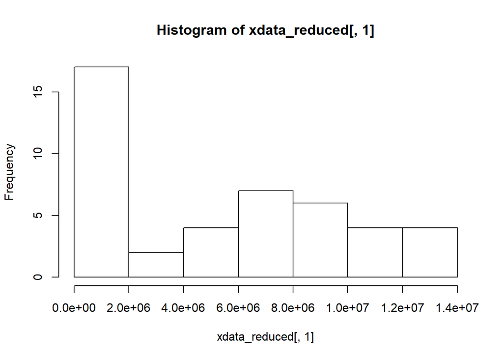

```r
hist(xdata_reduced[,1])
```

```r
message("\nSaphiro p-value of C10 (B): ", shapiro.test(xdata_reduced[,10])$p.value)
```

```
##
## Saphiro p-value of C10 (B): 0.0149865387234023
```

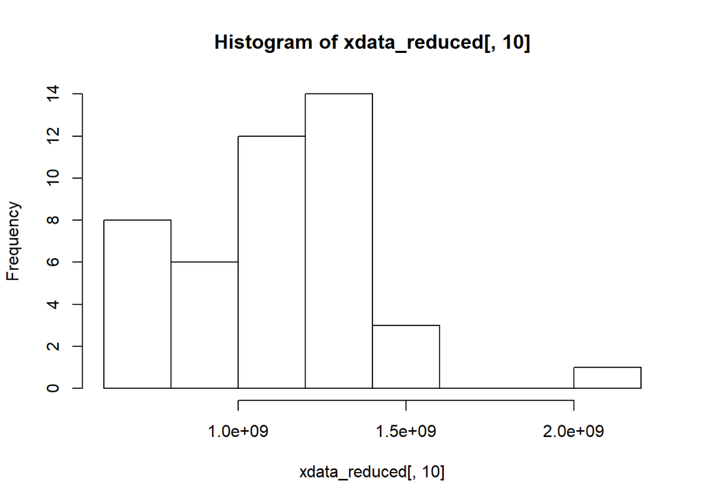

```r
hist(xdata_reduced[,10])
```

```r
#homocedasticity
X_c <- cbind(xdata_reduced, classes = classes)
homocedasticity <- function(x){leveneTest(x, group = factor(classes), data = X_c)}

p.levene <- NULL
fdr.p <- NULL
res.homo <- apply(data.matrix(xdata_reduced), 2, homocedasticity)
p.levene <- unlist(lapply(res.homo, function(x) { x["Pr(>F)"][1,]}))
names(p.levene) <- colnames(xdata_reduced)
fdr.p <- p.adjust(p.levene, "fdr")
p.levene = as.data.frame(p.levene)
p.levene$id = row.names(p.levene)
saphiro = merge(saphiro, p.levene, by = "id")
#FDR
fdr.levene <- p.adjust(saphiro$p.levene, method = "fdr", n = length(saphiro$p.levene))
saphiro <- cbind(saphiro, fdr.levene)
message("\nNumber of features with heteroscedasticity: ",
sum(saphiro$fdr.levene < 0.05), " of ", length(saphiro$fdr.levene))
```

```
##
## Number of features with heteroscedasticity: 234 of 2967
```

```r
sum(saphiro$p.levene < 0.05)
```

```
## [1] 681
```

```r
head(saphiro[saphiro$fdr.levene < 0.05,1])
```

```
## [1] "1005.59683736435_58.2009703606139" "1006.49228334575_62.3371608343449"
## [3] "1015.6716367533_149.087238404391"  "102.127989527503_115.696797107312"
## [5] "103.131500851993_60.4545574061347" "1045.72015258906_146.797695495675"
```

## Getting means

```r
abcd <- data.frame(apply(FUN=mean, MARGIN=2, X=xdata_reduced))
colnames(abcd) <- c("Means")
abcd$id <- row.names(abcd)
result <- abcd[c(2,1)]

subcases <- subset(X_c, X_c[,"classes"]==classes[1])
abcd <- data.frame(apply(FUN=median, MARGIN=2, X=subcases[,1:dim(subcases)[2]-1]))
colnames(abcd) <- c("MedianCases")
abcd$id <- row.names(abcd)
result <- merge(result,abcd, by ="id")

abcd <- data.frame(apply(FUN=sd, MARGIN=2, X=subcases[,1:dim(subcases)[2]-1]))
colnames(abcd) <- c("SDCases")
abcd$id <- row.names(abcd)
result <- merge(result,abcd, by ="id")

subcontrols <- subset(X_c, X_c[,"classes"]==classes[2])
abcd <- data.frame(apply(FUN=median, MARGIN=2, X=subcontrols[,1:dim(subcontrols)[2]-1]))
colnames(abcd) <- c("MedianControls")
abcd$id <- row.names(abcd)
result <- merge(result,abcd, by ="id")

abcd <- data.frame(apply(FUN=sd, MARGIN=2, X=subcontrols[,1:dim(subcontrols)[2]-1]))
colnames(abcd) <- c("SDControls")
abcd$id <- row.names(abcd)
result <- merge(result,abcd, by ="id")

result <- merge(saphiro, result, by = "id")
```

## Model

```r
library(nlme)
stat <- function(x){wilcox.test(x ~ classes, X_c)$p.value}
abcd <- data.frame(apply(FUN = stat,
                         MARGIN = 2,
                         X = xdata_reduced))
colnames(abcd) <- c("p_Wilc_Binary")
abcd$id <- row.names(abcd)
result <- merge(result, abcd, all = TRUE, by= "id")
```

```r
summary(result$p_Wilc_Binary)
```

```
##     Min.  1st Qu.   Median     Mean  3rd Qu.     Max.
## 0.000000 0.005398 0.087973 0.239538 0.414166 1.000000
```

```r
message("\nNumber of features < 0.05 nominal p-value ",
sum(result$p_Wilc_Binary < 0.05))
```

```
##
## Number of features < 0.05 nominal p-value 1276
```

```r
head(result[result$p_Wilc_Binary < 0.05,1])
```

```
## [1] "100.075900463872_43.7121413657807" "100.11238753709_57.9630176633643"
## [3] "100.510508936795_284.174369416944" "1005.59683736435_58.2009703606139"
## [5] "1006.49228334575_62.3371608343449" "1006.49696275667_62.2715556129121"
```

## FDR correction

```r
#FDR
fdr.wilcox <- p.adjust(result$p_Wilc_Binary, method = "fdr",
                       n = length(result$p_Wilc_Binary))
result <- cbind(result, fdr.wilcox)
message("\nNumber of features fdr-corrected p value of < 0.05 is ",
sum(result$fdr.wilcox < 0.05))
```

```
##
## Number of features fdr-corrected p value of < 0.05 is 984
```

## Univariante analisys negative

## Check normality

```r
library(car)
normality <- function(x){shapiro.test(x)$p.value}

abcd <- data.frame(apply(FUN=normality, MARGIN=2, X= xdata_reduced_neg))
abcd$id <- row.names(abcd)
colnames(abcd) <- c("shapiro.test", "id")
saphiro <- abcd

#correcion fdr
fdr.saphiro <- p.adjust(saphiro$shapiro.test, method = "fdr", n = length(saphiro$shapiro.test))
saphiro <- cbind(saphiro, fdr.saphiro)
message("\nNumber of features with non-normal distribution at xdata_reduced: ",
        sum(saphiro$fdr.saphiro < 0.05), " of ", length(saphiro$shapiro.test))
```

```
##
## Number of features with non-normal distribution at xdata_reduced: 1682 of 1873
```

```r
sum(saphiro$shapiro.test<0.05)
```

```
## [1] 1692
```

```r
#chechar con un jemplo para ver si funciona
message("\nSaphiro p-value of C1 (B): ", shapiro.test(xdata_reduced[,1])$p.value)
```

```
##
## Saphiro p-value of C1 (B): 0.000505141055518159
```

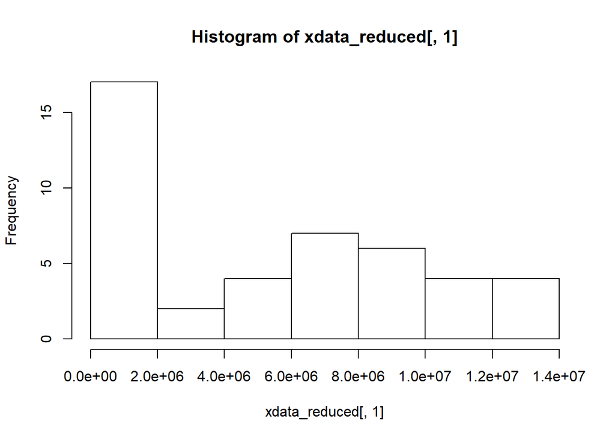

```r
hist(xdata_reduced[,1])
```

```r
message("\nSaphiro p-value of C10 (B): ", shapiro.test(xdata_reduced[,10])$p.value)
```

```
##
## Saphiro p-value of C10 (B): 0.0149865387234023
```

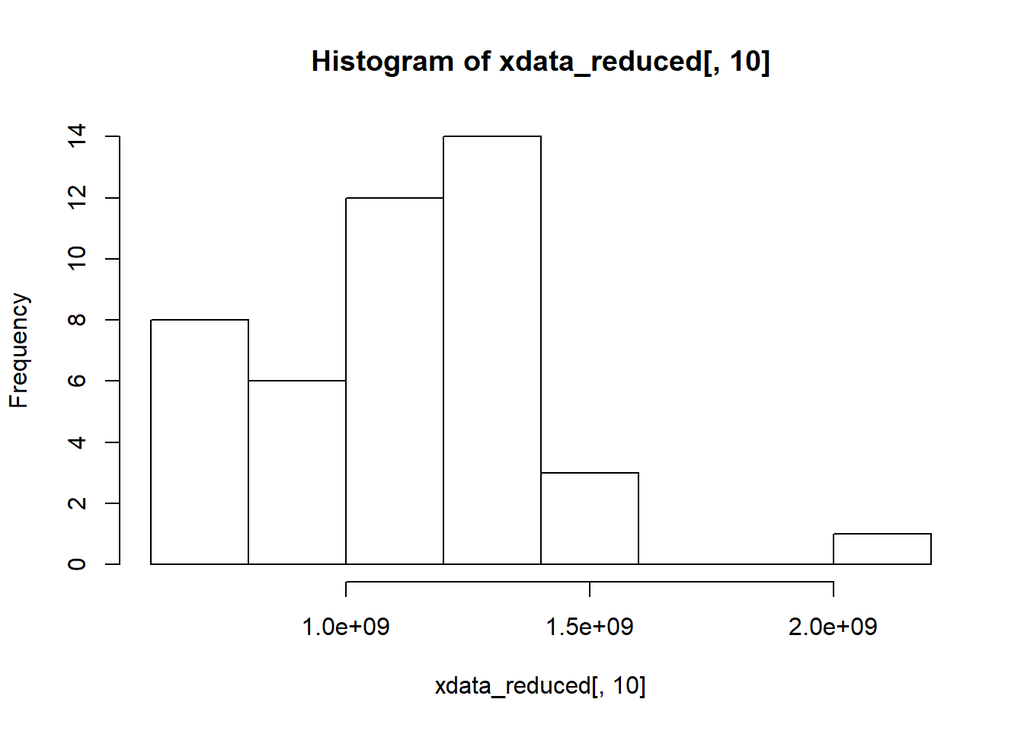

```r
hist(xdata_reduced[,10])
```

```r
#homocedasticity
X_c_neg <- cbind(xdata_reduced_neg, classes = classes_neg)
homocedasticity <- function(x){leveneTest(x, group = factor(classes_neg), data = X_c_neg)}

p.levene <- NULL
fdr.p <- NULL
res.homo <- apply(data.matrix(xdata_reduced_neg), 2, homocedasticity)
p.levene <- unlist(lapply(res.homo, function(x) { x["Pr(>F)"][1,]}))
names(p.levene) <- colnames(xdata_reduced_neg)
fdr.p <- p.adjust(p.levene, "fdr")
p.levene = as.data.frame(p.levene)
p.levene$id = row.names(p.levene)
saphiro = merge(saphiro, p.levene, by = "id")
#FDR
fdr.levene <- p.adjust(saphiro$p.levene, method = "fdr", n = length(saphiro$p.levene))
saphiro <- cbind(saphiro, fdr.levene)
message("\nNumber of features with heteroscedasticity: ",
sum(saphiro$fdr.levene < 0.05), " of ", length(saphiro$fdr.levene))
```

```
##
## Number of features with heteroscedasticity: 127 of 1873
```

```r
sum(saphiro$p.levene < 0.05)
```

```
## [1] 482
```

```r
head(saphiro[saphiro$fdr.levene < 0.05,1])
```

```
## [1] "1045.63999278722_198.035336451069" "1059.66843294191_202.121115228862"
## [3] "1098.62660336176_30.1834642547046" "115.944050673955_194.555256396352"
## [5] "117.930318298774_98.3620418657855" "1224.52313835687_155.884056079226"
```

## Getting means

```r
abcd <- data.frame(apply(FUN=mean, MARGIN=2, X=xdata_reduced_neg))
colnames(abcd) <- c("Means")
abcd$id <- row.names(abcd)
result_neg <- abcd[c(2,1)]

subcases <- subset(X_c_neg, X_c_neg[,"classes"]==classes_neg[1])
abcd <- data.frame(apply(FUN=median, MARGIN=2, X=subcases[,1:dim(subcases)[2]-1]))
colnames(abcd) <- c("MedianCases")
abcd$id <- row.names(abcd)
result_neg <- merge(result_neg,abcd, by ="id")

abcd <- data.frame(apply(FUN=sd, MARGIN=2, X=subcases[,1:dim(subcases)[2]-1]))
colnames(abcd) <- c("SDCases")
abcd$id <- row.names(abcd)
result_neg <- merge(result_neg,abcd, by ="id")

subcontrols <- subset(X_c_neg, X_c_neg[,"classes"]==classes_neg[2])
abcd <- data.frame(apply(FUN=median, MARGIN=2, X=subcontrols[,1:dim(subcontrols)[2]-1]))
colnames(abcd) <- c("MedianControls")
abcd$id <- row.names(abcd)
result_neg <- merge(result_neg,abcd, by ="id")

abcd <- data.frame(apply(FUN=sd, MARGIN=2, X=subcontrols[,1:dim(subcontrols)[2]-1]))
colnames(abcd) <- c("SDControls")
abcd$id <- row.names(abcd)
result_neg <- merge(result_neg,abcd, by ="id")

result_neg <- merge(saphiro, result_neg, by = "id")
```

## Model

```r
library(nlme)

stat <- function(x){wilcox.test(x ~ classes_neg, X_c_neg)$p.value}
abcd <- data.frame(apply(FUN = stat,
                         MARGIN = 2,
                         X = xdata_reduced_neg))
colnames(abcd) <- c("p_Wilc_Binary")
abcd$id <- row.names(abcd)
result_neg <- merge(result_neg, abcd, all = TRUE, by= "id")
```

```r
summary(result_neg$p_Wilc_Binary)
```

```
##    Min. 1st Qu.  Median    Mean 3rd Qu.    Max.
## 0.00000 0.01342 0.16260 0.29079 0.51295 1.00000
```

```r
message("\nNumber of features < 0.05 nominal p-value ",
sum(result_neg$p_Wilc_Binary < 0.05))
```

```
##
## Number of features < 0.05 nominal p-value 659
```

```r
head(result_neg[result_neg$p_Wilc_Binary < 0.05,1])
```

```
## [1] "100.926308861851_218.511437211666" "102.956999155513_16.8658739561995"
## [3] "1045.63999278722_198.035336451069" "1047.70520108185_209.663551398147"
## [5] "1059.66843294191_202.121115228862" "106.041329615059_274.563404352906"
```

## FDR correction

```r
#FDR
fdr.wilcox <- p.adjust(result_neg$p_Wilc_Binary, method = "fdr", n = length(result_neg$p_Wilc_Binary))
result_neg <- cbind(result_neg, fdr.wilcox)
message("\nNumber of features fdr-corrected p value of < 0.05 is ",
sum(result_neg$fdr.wilcox < 0.05))
```

```
##
## Number of features fdr-corrected p value of < 0.05 is 456
```

# Univariate anotation postivie

```r
# We use the selected vips
univ_feat <- result[result$fdr.wilcox < 0.05,1]

# Untargeted assignation
# Creating mz column
mzr <- univ_feat %>%
  stringr::str_split(.,"\\_") %>%
  lapply(.,function(x) x[1]) %>%
  unlist() %>%
  as.numeric()

all.equal(dim(univ_feat)[2], length(mzr))
```

```
## [1] "target is NULL, current is numeric"
```

```r
#Guardo las masas
output_dir_node10 <- file.path(output_dir, "10-univariante_pos")
fs::dir_create(output_dir_node10)
result_POS_HMDB_fn <- file.path(output_dir_node10,
                               "result_POS_mz_univ.csv")
utils::write.csv(mzr,
                 result_POS_HMDB_fn,
                 row.names = FALSE)

tdata_reduced_univ <- data.frame(mz = mzr)
result_POS_HMDB_univ <- assignation_pos_HMDB(tdata_reduced_univ)
head(result_POS_HMDB_univ)
```

|  | mz | HMDB | Assignation |
| --- | --- | --- | --- |
| 1 | 100.0759 | HMDB11749 | 2-Piperidinone |
| 2 | 100.5105 | NA | NA |
| 3 | 1005.5968 | NA | NA |
| 4 | 1006.4923 | NA | NA |
| 5 | 1006.4970 | NA | NA |
| 6 | 1008.4917 | NA | NA |

# Univariate annotation negative

```r
# We use the selected vips
univ_feat_neg <- result_neg[result_neg$fdr.wilcox < 0.05,1]

# Untargeted assignation
# Creating mz column
mzr_neg <- univ_feat_neg %>%
  stringr::str_split(.,"\\_") %>%
  lapply(.,function(x) x[1]) %>%
  unlist() %>%
  as.numeric()

all.equal(dim(univ_feat_neg)[2], length(mzr_neg))
```

```
## [1] "target is NULL, current is numeric"
```

```r
#Guardo las masas
output_dir_node10 <- file.path(output_dir, "10-univariante_neg")
fs::dir_create(output_dir_node10)
result_NEG_HMDB_fn <- file.path(output_dir_node10,
                               "result_POS_mz_univ_neg.csv")
utils::write.csv(mzr_neg,
                 result_NEG_HMDB_fn,
                 row.names = FALSE)

tdata_reduced_univ_neg <- data.frame(mz = mzr_neg)
result_NEG_HMDB_univ <- assignation_neg_HMDB(tdata_reduced_univ_neg)
head(result_NEG_HMDB_univ)
```

|  | mz | HMDB | Assignation |
| --- | --- | --- | --- |
| 1 | 100.9263 | NA | NA |
| 2 | 1045.6400 | NA | NA |
| 3 | 1047.7052 | NA | NA |
| 4 | 1059.6684 | NA | NA |
| 5 | 1061.6840 | NA | NA |
| 6 | 1062.6862 | NA | NA |

# anotation of all features positive

```r
# Untargeted assignation
# Creating mz column

mzr <- colnames(as.matrix(xdataImputed)) %>%
  stringr::str_split(.,"\\_") %>%
  lapply(.,function(x) x[1]) %>%
  unlist() %>%
  as.numeric()

all.equal(dim(xdataImputed)[2], length(mzr))
```

```
## [1] TRUE
```

```r
#Guardo las masas
output_dir_node10 <- file.path(output_dir, "10-all_features_pos")
fs::dir_create(output_dir_node10)
result_POS_HMDB_fn <- file.path(output_dir_node10,
                               "result_POS_all_features.csv")
utils::write.csv(mzr,
                 result_POS_HMDB_fn,
                 row.names = FALSE)

tdata_reduced_all_features <- data.frame(mz = mzr)
result_POS_HMDB_all_features <- assignation_pos_HMDB(tdata_reduced_all_features)
head(result_POS_HMDB_all_features)
```

|  | mz | HMDB | Assignation |
| --- | --- | --- | --- |
| 1 | 85.07624 | NA | NA |
| 2 | 85.08432 | NA | NA |
| 3 | 86.00254 | NA | NA |
| 4 | 86.06026 | HMDB02039 | 2-Pyrrolidinone |
| 5 | 86.06022 | HMDB02039 | 2-Pyrrolidinone |
| 6 | 86.08193 | NA | NA |

```r
all_features_anotation_fn <- file.path(output_dir_node10,
                               "all_features_anotation_pos.csv")
utils::write.csv(result_POS_HMDB_all_features,
                 all_features_anotation_fn,
                 row.names = FALSE)
```

# anotation of all features negative

```r
# Untargeted assignation
# Creating mz column

mzr_neg <- colnames(as.matrix(xdataImputed_neg)) %>%
  stringr::str_split(.,"\\_") %>%
  lapply(.,function(x) x[1]) %>%
  unlist() %>%
  as.numeric()

all.equal(dim(xdataImputed_neg)[2], length(mzr_neg))
```

```
## [1] TRUE
```

```r
#Guardo las masas
output_dir_node10 <- file.path(output_dir, "10-all_features_neg")
fs::dir_create(output_dir_node10)
result_NEG_HMDB_fn <- file.path(output_dir_node10,
                               "result_NEG_all_features.csv")
utils::write.csv(mzr_neg,
                 result_NEG_HMDB_fn,
                 row.names = FALSE)

tdata_reduced_all_features_neg <- data.frame(mz = mzr_neg)
result_NEG_HMDB_all_features <- assignation_neg_HMDB(tdata_reduced_all_features_neg)
head(result_NEG_HMDB_all_features)
```

|  | mz | HMDB | Assignation |
| --- | --- | --- | --- |
| 1 | 87.00918 | HMDB11111 --- HMDB00243 | Malonic semialdehyde --- Pyruvic acid |
| 2 | 87.00900 | HMDB11111 --- HMDB00243 | Malonic semialdehyde --- Pyruvic acid |
| 3 | 87.00895 | HMDB11111 --- HMDB00243 | Malonic semialdehyde --- Pyruvic acid |
| 4 | 87.28806 | NA | NA |
| 5 | 87.92554 | NA | NA |
| 6 | 88.00422 | NA | NA |

```r
all_features_anotation_fn <- file.path(output_dir_node10,
                               "all_features_anotation_neg.csv")
utils::write.csv(result_NEG_HMDB_all_features,
                 all_features_anotation_fn,
                 row.names = FALSE)
```

# NODE 11: Annotation

HMDB metabolites in positive and negative ionization The function compares (M+H & M-H) mass of metabolites contained in the The Human Metabolome Database (HMDB) (+- 1.007276) with features from the ionized feature table (window of +-0.002).

@param feature_table A dataframe containing feature in rows and samples in columns. A column called “mz” is required with the correspoinding mass of each feature.

@return The same feature table with two extra column with matched metabolites (HMDB code and assignation).

## Code to run

```r
# We use the selected vips
xdata_vips <- xdata_reduced[,rownames(VIPs)]

# Untargeted assignation
# Creating mz column
mzr <- colnames(xdata_vips) %>%
  stringr::str_split(.,"\\_") %>%
  lapply(.,function(x) x[1]) %>%
  unlist() %>%
  as.numeric()

all.equal(dim(xdata_vips)[2], length(mzr))
```

```
## [1] TRUE
```

```r
# We recover the ramcluster vips mz whitout adduct mass and add a proton
clustered_mzr <- mzr[mzr %in% Representative_ions$mz]
clustered_mzr <- cluster_data[cluster_data$Max_int_ion_mz %in%
                                clustered_mzr, "RC_mz"] - 1.0073
singletons_mzr <- mzr[!mzr %in% Representative_ions$mz]

mzr_RC <- c(clustered_mzr, singletons_mzr)

tdata_reduced <- data.frame(mz = mzr)
result_POS_HMDB_vips <- assignation_pos_HMDB(tdata_reduced)
head(result_POS_HMDB_vips)
```

|  | mz | HMDB | Assignation |
| --- | --- | --- | --- |
| 1 | 750.5423 | HMDB09413 --- HMDB09414 --- HMDB09446 --- HMDB09447 --- HMDB09478 --- HMDB09642 --- HMDB09675 --- HMDB11359 --- HMDB11360 --- HMDB11387 --- HMDB11418 --- HMDB11419 --- HMDB11451 --- HMDB11452 | PE(20:4(5Z,8Z,11Z,14Z)/P-18:1(11Z)) --- PE(20:4(5Z,8Z,11Z,14Z)/P-18:1(9Z)) --- PE(20:4(8Z,11Z,14Z,17Z)/P-18:1(11Z)) --- PE(20:4(8Z,11Z,14Z,17Z)/P-18:1(9Z)) --- PE(20:5(5Z,8Z,11Z,14Z,17Z)/P-18:0) --- P… |
| 2 | 798.5481 | NA | NA |
| 3 | 205.0976 | HMDB13609 --- HMDB00929 | D-Tryptophan --- L-Tryptophan |
| 4 | 750.8156 | NA | NA |
| 5 | 420.7643 | NA | NA |
| 6 | 318.3003 | HMDB04610 | Phytosphingosine |

```r
tdata_clusters <- data.frame(mz = Representative_ions$mz)
result_POS_HMDB_clusters <- assignation_pos_HMDB(tdata_clusters)
head(result_POS_HMDB_clusters)
```

|  | mz | HMDB | Assignation |
| --- | --- | --- | --- |
| 1 | 253.12054 | NA | NA |
| 2 | 96.92206 | NA | NA |
| 3 | 362.92665 | NA | NA |
| 4 | 398.74206 | NA | NA |
| 5 | 314.77887 | NA | NA |
| 6 | 330.75439 | NA | NA |

```r
tdata_reduced_RC <- data.frame(mz = mzr_RC)
result_POS_HMDB_vips_less_RCadduct <- assignation_pos_HMDB(tdata_reduced_RC)
head(result_POS_HMDB_vips_less_RCadduct)
```

|  | mz | HMDB | Assignation |
| --- | --- | --- | --- |
| 1 | 373.7702 | NA | NA |
| 2 | 316.2857 | NA | NA |
| 3 | 276.2337 | NA | NA |
| 4 | 796.5335 | NA | NA |
| 5 | 116.0721 | HMDB12880 --- HMDB03411 --- HMDB00162 | Acetamidopropanal --- D-Proline --- L-Proline |
| 6 | 742.5763 | NA | NA |

```r
# We use the selected vips
xdata_vips_neg <- xdata_reduced_neg[,rownames(VIPs_neg)]

# Untargeted assignation
# Creating mz column
mzr_neg <- colnames(xdata_vips_neg) %>%
  stringr::str_split(.,"\\_") %>%
  lapply(.,function(x) x[1]) %>%
  unlist() %>%
  as.numeric()

all.equal(dim(xdata_vips_neg)[2], length(mzr_neg))
```

```
## [1] TRUE
```

```r
# We recover the ramcluster vips mz whitout adduct mass and add a proton
clustered_mzr_neg <- mzr_neg[mzr_neg %in% Representative_ions_neg$mz]
clustered_mzr_neg <- cluster_data_neg[cluster_data_neg$Max_int_ion_mz %in%
                                        clustered_mzr_neg, "RC_mz"] - 1.0073
singletons_mzr_neg <- mzr_neg[!mzr_neg %in% Representative_ions_neg$mz]

mzr_RC_neg <- c(clustered_mzr_neg, singletons_mzr_neg)

tdata_reduced_neg <- data.frame(mz = mzr_neg)
result_NEG_HMDB_vips <- assignation_neg_HMDB(tdata_reduced_neg)
head(result_NEG_HMDB_vips)
```

|  | mz | HMDB | Assignation |
| --- | --- | --- | --- |
| 1 | 244.9089 | NA | NA |
| 2 | 1045.6400 | NA | NA |
| 3 | 462.3001 | NA | NA |
| 4 | 464.3133 | NA | NA |
| 5 | 374.2557 | NA | NA |
| 6 | 844.5946 | NA | NA |

```r
tdata_clusters_neg <- data.frame(mz = Representative_ions_neg$mz)
result_NEG_HMDB_clusters <- assignation_neg_HMDB(tdata_clusters_neg)
head(result_NEG_HMDB_clusters)
```

|  | mz | HMDB | Assignation |
| --- | --- | --- | --- |
| 1 | 335.2217 | HMDB04696 --- HMDB04693 --- HMDB04692 --- HMDB04243 --- HMDB05089 --- HMDB10204 --- HMDB04244 --- HMDB05050 --- HMDB10211 --- HMDB01193 --- HMDB10216 --- HMDB11135 --- HMDB05088 --- HMDB05087 --- HMDB… | 11(R)-HPETE --- 11H-14,15-EETA --- 12(R)-HPETE --- 12(S)-HPETE --- 12(S)-Leukotriene B4 --- 14,15-DiHETE --- 15(S)-HPETE --- 15H-11,12-EETA --- 17,18-DiHETE --- 5(S)-Hydroperoxyeicosatetraenoic acid -… |
| 2 | 92.9284 | NA | NA |
| 3 | 197.8079 | NA | NA |
| 4 | 670.7245 | NA | NA |
| 5 | 367.2130 | HMDB04242 --- HMDB01908 --- HMDB03247 --- HMDB12110 --- HMDB01979 --- HMDB04241 --- HMDB03235 --- HMDB05099 | 11-Dehydro-thromboxane B2 --- 19-Hydroxy-PGE2 --- 20-Hydroxy-PGE2 --- 5(6)-Epoxy Prostaglandin E1 --- 6,15-Diketo,13,14-dihydro-PGF1a --- 6-Ketoprostaglandin E1 --- Prostaglandin G2 --- Thromboxane B3 |
| 6 | 672.7202 | NA | NA |

```r
tdata_reduced_RC_neg <- data.frame(mz = mzr_RC_neg)
result_NEG_HMDB_vips_less_RCadduct <- assignation_neg_HMDB(tdata_reduced_RC_neg)
head(result_NEG_HMDB_vips_less_RCadduct)
```

|  | mz | HMDB | Assignation |
| --- | --- | --- | --- |
| 1 | 197.8079 | NA | NA |
| 2 | 462.3001 | NA | NA |
| 3 | 374.2557 | NA | NA |
| 4 | 244.9089 | NA | NA |
| 5 | 1092.7359 | NA | NA |
| 6 | 706.7017 | NA | NA |

```r
# Untargeted assignation
# Creating mz column
mzr <- colnames(xdata_reduced) %>%
  stringr::str_split(.,"\\_") %>%
  lapply(.,function(x) x[1]) %>%
  unlist() %>%
  as.numeric()

all.equal(dim(xdata_reduced)[2], length(mzr))
```

```
## [1] TRUE
```

```r
tdata_reduced <- data.frame(mz = mzr)
result_POS_HMDB_reduced <- assignation_pos_HMDB(tdata_reduced)
head(result_POS_HMDB_reduced)
```

|  | mz | HMDB | Assignation |
| --- | --- | --- | --- |
| 1 | 86.06026 | HMDB02039 | 2-Pyrrolidinone |
| 2 | 86.08193 | NA | NA |
| 3 | 86.09687 | NA | NA |
| 4 | 86.09686 | NA | NA |
| 5 | 88.07597 | HMDB01080 | 4-Aminobutyraldehyde |
| 6 | 88.07611 | HMDB01080 | 4-Aminobutyraldehyde |

```r
# Untargeted assignation
# Creating mz column
mzr_neg <- colnames(xdata_reduced_neg) %>%
  stringr::str_split(.,"\\_") %>%
  lapply(.,function(x) x[1]) %>%
  unlist() %>%
  as.numeric()

all.equal(dim(xdata_reduced_neg)[2], length(mzr_neg))
```

```
## [1] TRUE
```

```r
tdata_reduced_neg <- data.frame(mz = mzr_neg)
result_NEG_HMDB_reduced <- assignation_neg_HMDB(tdata_reduced_neg)
head(result_NEG_HMDB_reduced)
```

|  | mz | HMDB | Assignation |
| --- | --- | --- | --- |
| 1 | 87.00895 | HMDB11111 --- HMDB00243 | Malonic semialdehyde --- Pyruvic acid |
| 2 | 89.02470 | HMDB01882 --- HMDB01311 --- HMDB01051 --- HMDB00700 --- HMDB00190 | Dihydroxyacetone --- D-Lactic acid --- Glyceraldehyde --- Hydroxypropionic acid --- L-Lactic acid |
| 3 | 90.93378 | NA | NA |
| 4 | 90.93379 | NA | NA |
| 5 | 90.93388 | NA | NA |
| 6 | 92.92840 | NA | NA |

# Principal Component Analysis

```r
xdata_reduced_rows <- cbind(sampleNames =
                            rownames(xdata_vips),
                            xdata_vips)

suppressWarnings(
  xdata_reduc_comp_meta <- dplyr::right_join(
    metadata_pos,
    xdata_reduced_rows,
    by = "sampleNames",
    all = TRUE))

newmz <- c(colnames(xdata_reduc_comp_meta[1:7]), mzr)
newrt <- c(colnames(xdata_reduc_comp_meta[1:7]), rtr)
reduced_data_comp <- rbind(newrt, xdata_reduc_comp_meta)
reduced_data_comp <- rbind(newmz, reduced_data_comp)

pca_plot <- mixOmics::pca(as.matrix(xdata_reduced_rows[,-1]),
                          ncomp = 2,
                          center = TRUE,
                          scale = TRUE)

pca_plot
```

```
## Eigenvalues for the first 2 principal components, see object$sdev^2:
##      PC1      PC2
## 9.918070 2.099434
##
## Proportion of explained variance for the first 2 principal components, see object$explained_variance:
##       PC1       PC2
## 0.5510039 0.1166352
##
## Cumulative proportion explained variance for the first 2 principal components, see object$cum.var:
##       PC1       PC2
## 0.5510039 0.6676391
##
##  Other available components:
##  --------------------
##  loading vectors: see object$rotation
```

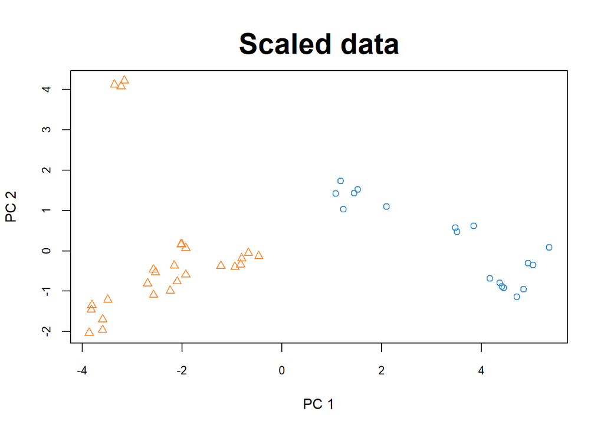

```r
plot_PCAtreat <- mixOmics::plotIndiv (pca_plot,
                     style = "graphics",
                     ind.names = FALSE,
                    #ind.names = xdata_reduc_comp_meta$treatment,
                     group = xdata_reduc_comp_meta$treatment,
                     legend = FALSE,
                     X.label = "PC 1",
                     Y.label = "PC 2",
                     title = "Scaled data")
```

```r
pca_plot <- mixOmics::pca(as.matrix(xdata_reduced_rows[,-1]),
                          ncomp = 2,
                          center = TRUE,
                          scale = FALSE)
pca_plot
```

```
## Eigenvalues for the first 2 principal components, see object$sdev^2:
##          PC1          PC2
## 5.521065e+17 3.846207e+16
##
## Proportion of explained variance for the first 2 principal components, see object$explained_variance:
##        PC1        PC2
## 0.89482044 0.06233697
##
## Cumulative proportion explained variance for the first 2 principal components, see object$cum.var:
##       PC1       PC2
## 0.8948204 0.9571574
##
##  Other available components:
##  --------------------
##  loading vectors: see object$rotation
```

```r
xdata_reduced_rows_neg <- cbind(sampleNames =
                            rownames(xdata_vips_neg),
                            xdata_vips_neg)

suppressWarnings(
  xdata_reduc_comp_meta_neg <- dplyr::right_join(
    metadata_neg,
    xdata_reduced_rows_neg,
    by = "sampleNames",
    all = TRUE))

newmz_neg <- c(colnames(xdata_reduc_comp_meta_neg[1:7]), mzr)
newrt_neg <- c(colnames(xdata_reduc_comp_meta_neg[1:7]), rtr_neg)
reduced_data_comp_neg <- rbind(newrt_neg, xdata_reduc_comp_meta_neg)
reduced_data_comp_neg <- rbind(newmz_neg, reduced_data_comp_neg)

pca_plot_neg <- mixOmics::pca(as.matrix(xdata_reduced_rows_neg[,-1]),
                          ncomp = 2,
                          center = TRUE,
                          scale = TRUE)

pca_plot_neg
```

```
## Eigenvalues for the first 2 principal components, see object$sdev^2:
##      PC1      PC2
## 4.498769 1.403905
##
## Proportion of explained variance for the first 2 principal components, see object$explained_variance:
##       PC1       PC2
## 0.4089790 0.1276277
##
## Cumulative proportion explained variance for the first 2 principal components, see object$cum.var:
##       PC1       PC2
## 0.4089790 0.5366067
##
##  Other available components:
##  --------------------
##  loading vectors: see object$rotation
```

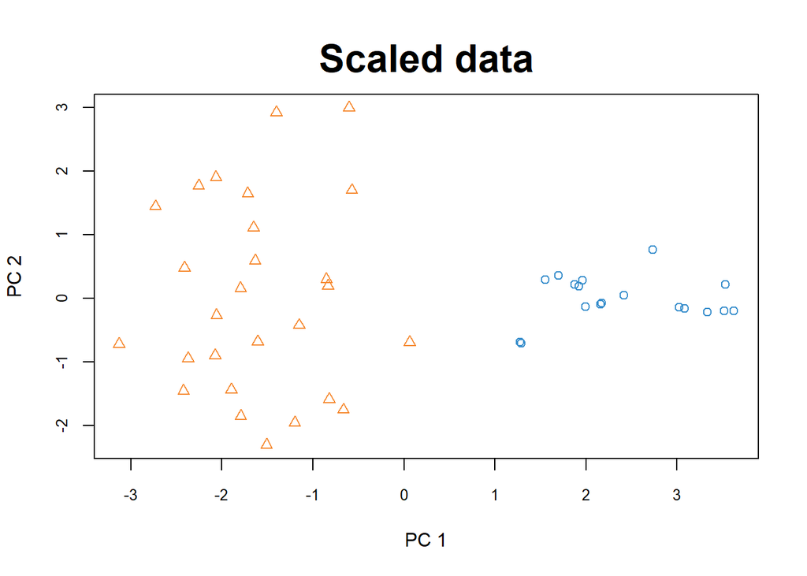

```r
plot_PCAtreat_neg <- mixOmics::plotIndiv (pca_plot_neg,
                     style = "graphics",
                     ind.names = FALSE,
                    #ind.names = xdata_reduc_comp_meta$treatment,
                     group = xdata_reduc_comp_meta_neg$treatment,
                     legend = FALSE,
                     X.label = "PC 1",
                     Y.label = "PC 2",
                     title = "Scaled data")
```

```r
pca_plot_neg <- mixOmics::pca(as.matrix(xdata_reduced_rows_neg[,-1]),
                          ncomp = 2,
                          center = TRUE,
                          scale = FALSE)

pca_plot_neg
```

```
## Eigenvalues for the first 2 principal components, see object$sdev^2:
##          PC1          PC2
## 7.586760e+17 5.598023e+14
##
## Proportion of explained variance for the first 2 principal components, see object$explained_variance:
##          PC1          PC2
## 0.9987998951 0.0007369818
##
## Cumulative proportion explained variance for the first 2 principal components, see object$cum.var:
##       PC1       PC2
## 0.9987999 0.9995369
##
##  Other available components:
##  --------------------
##  loading vectors: see object$rotation
```

## Save results

```r
output_dir_node11 <- file.path(output_dir, "11-identification")
fs::dir_create(output_dir_node11)

result_POS_HMDB_reduced_fn <- file.path(output_dir_node11,
                               "result_POS_HMDB_reduced.csv")
utils::write.csv(result_POS_HMDB_reduced,
                 result_POS_HMDB_reduced_fn,
                 row.names = FALSE)

result_POS_HMDB_fn <- file.path(output_dir_node11,
                               "result_POS_HMDB_vips.csv")
utils::write.csv(result_POS_HMDB_vips,
                 result_POS_HMDB_fn,
                 row.names = FALSE)

result_POS_HMDB_fn <- file.path(output_dir_node11,
                              "result_POS_HMDB_vips_less_adduct.csv")
utils::write.csv(result_POS_HMDB_vips_less_RCadduct,
                 result_POS_HMDB_fn,
                 row.names = FALSE)

result_POS_HMDB_fn <- file.path(output_dir_node11,
                               "result_POS_HMDB_univ.csv")
utils::write.csv(result_POS_HMDB_univ,
                 result_POS_HMDB_fn,
                 row.names = FALSE)

result_POS_HMDB_fn <- file.path(output_dir_node11,
                                "result_POS_HMDB_univ_nona.csv")
utils::write.csv(na.omit(result_POS_HMDB_univ),
                 result_POS_HMDB_fn,
                 row.names = FALSE)

result_NEG_HMDB_fn <- file.path(output_dir_node11,
                               "result_NEG_HMDB_univ.csv")
utils::write.csv(result_NEG_HMDB_univ,
                 result_NEG_HMDB_fn,
                 row.names = FALSE)

result_NEG_HMDB_fn <- file.path(output_dir_node11,
                                "result_NEG_HMDB_univ_nona.csv")
utils::write.csv(na.omit(result_NEG_HMDB_univ),
                 result_NEG_HMDB_fn,
                 row.names = FALSE)

xdata_reduc_comp_meta_fn <- file.path(output_dir_node11,
                               "xdata_reduc_comp_meta.csv")
utils::write.csv(xdata_reduc_comp_meta,
                 xdata_reduc_comp_meta_fn,
                 row.names = FALSE)

reduced_data_comp_fn <- file.path(output_dir_node11,
                               "xdata_reduc_comp_meta_MzRt.csv")
utils::write.csv(reduced_data_comp,
                 reduced_data_comp_fn,
                 row.names = FALSE)

cluster_data_fn <- file.path(output_dir_node11, "cluster_data_annotated.csv")
cluster_data_annotated <- cbind(cluster_data, result_POS_HMDB_clusters$Assignation)
utils::write.csv(cluster_data_annotated, cluster_data_fn, row.names = TRUE)
```

```r
output_dir_node11 <- file.path(output_dir, "11-identification")
fs::dir_create(output_dir_node11)

result_NEG_HMDB_reduced_fn <- file.path(output_dir_node11,
                               "result_NEG_HMDB_reduced.csv")
utils::write.csv(result_NEG_HMDB_reduced,
                 result_NEG_HMDB_reduced_fn,
                 row.names = FALSE)

result_NEG_HMDB_fn <- file.path(output_dir_node11,
                               "result_NEG_HMDB_vips.csv")
utils::write.csv(result_NEG_HMDB_vips,
                 result_NEG_HMDB_fn,
                 row.names = FALSE)

result_NEG_HMDB_fn <- file.path(output_dir_node11,
                              "result_NEG_HMDB_vips_less_adduct.csv")
utils::write.csv(result_NEG_HMDB_vips_less_RCadduct,
                 result_NEG_HMDB_fn,
                 row.names = FALSE)

xdata_reduc_comp_meta_fn <- file.path(output_dir_node11,
                               "xdata_reduc_comp_meta_neg.csv")
utils::write.csv(xdata_reduc_comp_meta_neg,
                 xdata_reduc_comp_meta_fn,
                 row.names = FALSE)

reduced_data_comp_fn <- file.path(output_dir_node11,
                               "xdata_reduc_comp_meta_MzRt_neg.csv")
utils::write.csv(reduced_data_comp_neg,
                 reduced_data_comp_fn,
                 row.names = FALSE)

cluster_data_fn <- file.path(output_dir_node11, "cluster_data_annotated_neg.csv")
cluster_data_annotated_neg <- cbind(cluster_data_neg, result_NEG_HMDB_clusters$Assignation)
utils::write.csv(cluster_data_annotated_neg, cluster_data_fn, row.names = TRUE)
```